# Практика · Відео: трекінг

> Лекція: lecture.html · Домашнє: homework.html · Тест: quiz.html

> ⏱ Зошит нічого не навчає — тут немає жодної нейромережі. Заміряно: **близько 20 секунд** на чотирьох ядрах без відеокарти. Найдовше йде `cv2.TrackerMIL` (десятки мілісекунд на кадр) і густий оптичний потік.

Що зробимо:

1. Збудуємо синтетичне відео, у якому **істина відома за побудовою**: пʼять куль літають по полю 96×96 сорок кадрів, і ми знаємо точну рамку кожної на кожному кадрі.
2. Заміряємо **оптичний потік** — `calcOpticalFlowFarneback` і `calcOpticalFlowPyrLK` — на зсуві, який задали самі. Побачимо, де він точний до сотих пікселя, а де мовчки бреше.
3. Спробуємо вести рамку **самим потоком** і подивимось, як швидко вона тікає.
4. Зберемо **трекінг за детекцією**: детектор на кожному кадрі плюс зіставлення угорським алгоритмом по IoU.
5. Уведемо метрику **підміна номера** (ID switch) і зʼясуємо, звідки підміни беруться.
6. Перевіримо **модель руху** й **фільтр Калмана** — і покажемо, за яких умов вони починають щось важити.
7. Порахуємо **MOTA** з трьома доданками й побачимо, чого вона не бачить.
8. Заміряємо єдиний трекер, що лишився в OpenCV 5, — `cv2.TrackerMIL`.

Кожна точка міряється на **вісьмох зернах**, і поряд із середнім друкується розкид. Різниця, менша за розкид, — не різниця.

```python
import sys, time
import numpy as np
import cv2
import matplotlib.pyplot as plt
from scipy.optimize import linear_sum_assignment

print("python  ", sys.version.split()[0])
print("cv2     ", cv2.__version__)
print("numpy   ", np.__version__)

# У OpenCV 5 модуля cv2.legacy більше немає — разом із ним пішли KCF, CSRT,
# MOSSE, MedianFlow і Boosting. Перевіряємо це, а не віримо памʼяті.
print("cv2.legacy є:", hasattr(cv2, "legacy"))
print("трекери, що лишились:", [n for n in dir(cv2) if n.startswith("Tracker") and n.endswith("_create")])
```

```
python   3.12.2
cv2      5.0.0
numpy    2.5.1
cv2.legacy є: False
трекери, що лишились: ['TrackerDaSiamRPN_create', 'TrackerMIL_create', 'TrackerNano_create', 'TrackerVit_create']
```

## 1 · Сцена, у якій істина відома за побудовою

Знімати справжнє відео нам нема з чого: пакетів `decord` і `av` у середовищі немає, а тягнути файл із мережі зошит не має права. Але для цієї теми синтетика навіть краща: **ми знаємо точну рамку кожної кулі на кожному кадрі**, тож будь-яку помилку трекера можна порахувати, а не оцінити на око.

Пʼять куль радіуса 7 пікселів літають полем 96×96 і відбиваються від країв. Сорок кадрів. Це наскрізний приклад усієї теми.

```python
W = H = 96          # розмір кадру
N_BALLS = 5         # скільки куль у сцені
N_FRAMES = 40       # довжина відео
R = 7.0             # радіус кулі в пікселях


def make_scene(seed, n_balls=N_BALLS, n_frames=N_FRAMES, speed=2.2):
    """Кулі летять рівномірно й відбиваються від країв.

    Повертає масив рамок [кадр, куля, (x1, y1, x2, y2)] — це наша еталонна розмітка."""
    rng = np.random.default_rng(seed)
    pos = rng.uniform(R + 2, W - R - 2, size=(n_balls, 2))
    vel = rng.uniform(-speed, speed, size=(n_balls, 2))
    boxes = np.zeros((n_frames, n_balls, 4))
    for t in range(n_frames):
        boxes[t, :, 0] = pos[:, 0] - R
        boxes[t, :, 1] = pos[:, 1] - R
        boxes[t, :, 2] = pos[:, 0] + R
        boxes[t, :, 3] = pos[:, 1] + R
        pos = pos + vel
        # відбиття від стінки: дзеркалимо координату й міняємо знак швидкості
        for i in range(n_balls):
            for d in (0, 1):
                lo, hi = R, W - R
                if pos[i, d] < lo:
                    pos[i, d] = 2 * lo - pos[i, d]
                    vel[i, d] = -vel[i, d]
                if pos[i, d] > hi:
                    pos[i, d] = 2 * hi - pos[i, d]
                    vel[i, d] = -vel[i, d]
    return boxes


scene = make_scene(0)
centers = (scene[:, :, :2] + scene[:, :, 2:]) / 2
step = np.linalg.norm(np.diff(centers, axis=0), axis=2)

print("форма масиву рамок:", scene.shape, "— (кадр, куля, координати)")
print(f"середній зсув кулі за кадр: {step.mean():.4f} px")
print(f"найбільший зсув за кадр:    {step.max():.4f} px")
print(f"сторона рамки:              {2 * R:.1f} px")
```

```
форма масиву рамок: (40, 5, 4) — (кадр, куля, координати)
середній зсув кулі за кадр: 1.8750 px
найбільший зсув за кадр:    2.5920 px
сторона рамки:              14.0 px
```

Порахуймо це перекриття явно. IoU (intersection over union) ми вже вводили в темі 23: спільна площа, поділена на площу обʼєднання.

```python
def iou_matrix(a, b):
    """Матриця IoU: рядок — рамка з a, стовпець — рамка з b."""
    if len(a) == 0 or len(b) == 0:
        return np.zeros((len(a), len(b)))
    x1 = np.maximum(a[:, None, 0], b[None, :, 0])
    y1 = np.maximum(a[:, None, 1], b[None, :, 1])
    x2 = np.minimum(a[:, None, 2], b[None, :, 2])
    y2 = np.minimum(a[:, None, 3], b[None, :, 3])
    inter = np.clip(x2 - x1, 0, None) * np.clip(y2 - y1, 0, None)
    area_a = (a[:, 2] - a[:, 0]) * (a[:, 3] - a[:, 1])
    area_b = (b[:, 2] - b[:, 0]) * (b[:, 3] - b[:, 1])
    return inter / (area_a[:, None] + area_b[None, :] - inter + 1e-9)


# перевірка «наша реалізація = рахунок руками» на двох рамках, де все видно очима
a = np.array([[0.0, 0.0, 10.0, 10.0]])
b = np.array([[5.0, 0.0, 15.0, 10.0]])
manual = (5 * 10) / (100 + 100 - 5 * 10)      # спільна смуга 5×10, обʼєднання 150
assert np.allclose(iou_matrix(a, b)[0, 0], manual), "IoU розійшовся!"
print(f"✅ IoU збігається з рахунком руками: {iou_matrix(a, b)[0, 0]:.4f} = {manual:.4f}")

# а тепер — перекриття тієї самої кулі на сусідніх кадрах
same_ball = []
for t in range(N_FRAMES - 1):
    m = iou_matrix(scene[t], scene[t + 1])
    same_ball.append(np.diag(m))
same_ball = np.array(same_ball)
print(f"IoU однієї кулі між сусідніми кадрами: середній {same_ball.mean():.4f}, "
      f"найменший {same_ball.min():.4f}")
```

```
✅ IoU збігається з рахунком руками: 0.3333 = 0.3333
IoU однієї кулі між сусідніми кадрами: середній 0.7144, найменший 0.6097
```

## 2 · Намалюємо відео

Кулі мають бути **текстуровані**, а не залиті однією фарбою. Це не косметика: оптичний потік усередині однорідної плями не працює взагалі, і за пів години ми це заміряємо. Текстура їде разом із кулею, тож істинний зсув кожного пікселя кулі дорівнює зсуву її центра — знову ж таки, за побудовою.

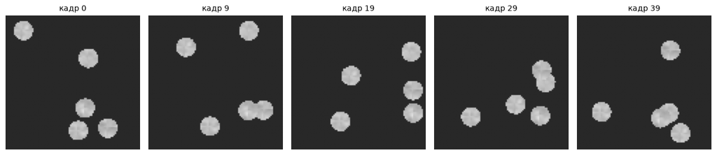

```
намальовано 40 кадрів (96, 96), тип uint8
```

```python
# одна велика текстура, з якої кожна куля бере свій шматок
TEX = cv2.GaussianBlur(np.random.default_rng(11).normal(190, 45, size=(3 * H, 3 * W)), (0, 0), 1.3)
TEX = np.clip(TEX, 0, 255).astype(np.uint8)
YY, XX = np.mgrid[0:H, 0:W]


def render(boxes_at_t, textured=True):
    """Малює один кадр за списком рамок. Текстура зсувається разом із кулею."""
    img = np.full((H, W), 40, np.uint8)
    for k in range(len(boxes_at_t)):
        cx = (boxes_at_t[k, 0] + boxes_at_t[k, 2]) / 2
        cy = (boxes_at_t[k, 1] + boxes_at_t[k, 3]) / 2
        mask = (XX - cx) ** 2 + (YY - cy) ** 2 <= R ** 2
        if textured:
            patch = TEX[k * 20:k * 20 + H, k * 20:k * 20 + W]
            patch = np.roll(np.roll(patch, int(round(cy)), 0), int(round(cx)), 1)
            img[mask] = patch[mask]
        else:
            img[mask] = 200
    return img


frames = [render(scene[t]) for t in range(N_FRAMES)]

fig, ax = plt.subplots(1, 5, figsize=(13, 2.8))
for j, t in enumerate([0, 9, 19, 29, 39]):
    ax[j].imshow(frames[t], cmap="gray", vmin=0, vmax=255)
    ax[j].set_title(f"кадр {t}", fontsize=10)
    ax[j].axis("off")
plt.tight_layout()
plt.show()
print(f"намальовано {len(frames)} кадрів {frames[0].shape}, тип {frames[0].dtype}")
```

## 3 · Оптичний потік: поле зсувів

**Оптичний потік** (optical flow) відповідає на питання «куди поїхав кожен піксель між цими двома кадрами». Відповідь — не число й не рамка, а **поле векторів** розміру кадру: для кожного пікселя пара (зсув по горизонталі, зсув по вертикалі).

Перевірити його чесно можна лише там, де істина відома. Тому спершу візьмемо суцільно текстовану картинку й **зсунемо її самі** на відоме число пікселів. Тоді правильна відповідь — та сама пара чисел у кожному пікселі.

```python
big = cv2.GaussianBlur(np.random.default_rng(5).normal(128, 40, size=(H + 60, W + 60)), (0, 0), 1.6)
big = np.clip(big, 0, 255).astype(np.uint8)


def cut(dx, dy):
    """Вирізає вікно H×W зі зсувом (dx, dy) — так ми задаємо істинний рух."""
    return big[30 - dy:30 - dy + H, 30 - dx:30 - dx + W].copy()


print(f"{'істинний зсув':>16}{'середня похибка':>18}{'медіана':>10}{'максимум':>11}")
farneback_rows = []
for dx, dy in [(1, 0), (2, 1), (3, 3), (5, 2), (8, 0), (12, 5)]:
    a_img, b_img = cut(0, 0), cut(dx, dy)
    flow = cv2.calcOpticalFlowFarneback(a_img, b_img, None,
                                        0.5, 3, 15, 3, 5, 1.2, 0)
    err = np.linalg.norm(flow - np.array([dx, dy], float), axis=2)
    farneback_rows.append((dx, dy, err.mean(), np.median(err), err.max()))
    print(f"{f'({dx}, {dy})':>16}{err.mean():>18.4f}{np.median(err):>10.4f}{err.max():>11.2f}")
```

```
   істинний зсув   середня похибка   медіана   максимум
          (1, 0)            0.0453    0.0139       0.95
          (2, 1)            0.1033    0.0311       2.15
          (3, 3)            0.2085    0.0600       4.13
          (5, 2)            0.2618    0.0746       5.23
          (8, 0)            3.0428    0.7008      13.20
         (12, 5)           13.8824   13.8988      19.05
```

Читай таблицю зверху вниз. На зсувах до пʼятьох пікселів медіана похибки — сотні пікселя. На зсуві (8, 0) медіана ще пристойна, а **середнє стрибає в дванадцять разів**: зіпсувалась не вся картинка, а окремі ділянки. На зсуві (12, 5) ламається все: похибка 13.88 при істинному зсуві довжиною 13.00 — тобто алгоритм відповів «нікуди не поїхало» майже скрізь.

Звідси перше практичне правило: **потік має стелю по швидкості**, і задає її розмір вікна разом із кількістю рівнів піраміди. Предмет, що проходить за кадр більше, ніж вікно, для потоку просто зникає.

## 4 · Апертурна проблема: усередині однорідної плями потоку немає

Тепер найважливіше про потік — і найменш очевидне. Візьмемо одну кулю й зсунемо її на (3, 2). Порівняємо два випадки: куля **залита однією фарбою** і куля **текстурована**.

```python
def one_ball(cx, cy, textured):
    img = np.full((H, W), 40, np.uint8)
    mask = (XX - cx) ** 2 + (YY - cy) ** 2 <= 20 ** 2
    if textured:
        patch = np.roll(np.roll(TEX[:H, :W], int(cy), 0), int(cx), 1)
        img[mask] = patch[mask]
    else:
        img[mask] = 200
    return img


true_shift = np.array([3.0, 2.0])
inner = (XX - 40) ** 2 + (YY - 48) ** 2 <= 12 ** 2                     # глибоко всередині
edge = (((XX - 40) ** 2 + (YY - 48) ** 2 <= 22 ** 2) &
        ((XX - 40) ** 2 + (YY - 48) ** 2 >= 17 ** 2))                  # кільце вздовж межі

for textured in (False, True):
    a_img = one_ball(40, 48, textured)
    b_img = one_ball(43, 50, textured)
    flow = cv2.calcOpticalFlowFarneback(a_img, b_img, None, 0.5, 3, 15, 3, 5, 1.2, 0)
    v_in = flow[inner].mean(axis=0)
    v_edge = flow[edge].mean(axis=0)
    name = "текстурована" if textured else "однорідна   "
    print(f"{name} куля:")
    print(f"    усередині потік = ({v_in[0]:.4f}, {v_in[1]:.4f}), "
          f"похибка {np.linalg.norm(flow[inner] - true_shift, axis=1).mean():.4f} px")
    print(f"    на межі   потік = ({v_edge[0]:.4f}, {v_edge[1]:.4f}), "
          f"похибка {np.linalg.norm(flow[edge] - true_shift, axis=1).mean():.4f} px")
print(f"істинний зсув = (3.0000, 2.0000)")
```

```
однорідна    куля:
    усередині потік = (1.5369, 1.0246), похибка 1.7585 px
    на межі   потік = (2.9999, 1.9999), похибка 0.0001 px
текстурована куля:
    усередині потік = (2.9922, 1.9948), похибка 0.0094 px
    на межі   потік = (2.9999, 1.9999), похибка 0.0001 px
істинний зсув = (3.0000, 2.0000)
```

Ось воно. На **межі** обидві кулі дають майже точний зсув. А **всередині однорідної** кулі потік дає приблизно половину правильного вектора — і це не випадковість, а математика: якщо в околі пікселя яскравість однакова скрізь, то зсув цього околу неможливо визначити, бо після зсуву картинка виглядає так само. Алгоритм заповнює порожнечу, розмазуючи відповідь із країв усередину, і чим глибше — тим слабше.

Це зветься **апертурна проблема**: дивлячись у маленьке віконце на однорідну поверхню, ти не бачиш руху. Варто додати кулі текстуру — і похибка всередині падає до тисячних пікселя.

Практичний наслідок: густий потік точний рівно там, де в зображенні є **малюнок**. На стіні, на снігу, на чистому небі його немає, а число він однаково поверне.

## 5 · Розріджений потік: `calcOpticalFlowPyrLK`

Із цього спостереження й народився другий підхід: не рахувати потік скрізь, а **обрати точки, де його можна порахувати**, і вести тільки їх. Кути — саме такі точки: в околі кута яскравість міняється в обох напрямках, тож апертурної проблеми немає. Це прямий нащадок теми 05 про класичні ознаки.

```python
a_img = one_ball(40, 48, textured=True)
b_img = one_ball(43, 50, textured=True)

corners = cv2.goodFeaturesToTrack(a_img, maxCorners=60, qualityLevel=0.01, minDistance=4)
moved, status, _ = cv2.calcOpticalFlowPyrLK(a_img, b_img, corners, None,
                                            winSize=(15, 15), maxLevel=3)
ok = status.ravel() == 1
shift = (moved - corners).reshape(-1, 2)[ok]

print(f"кутів знайдено:        {len(corners)}")
print(f"успішно проведено:     {int(ok.sum())}")
print(f"середній зсув:         ({shift[:, 0].mean():.4f}, {shift[:, 1].mean():.4f})")
print(f"істинний зсув:         (3.0000, 2.0000)")
print(f"середня похибка:       {np.linalg.norm(shift - true_shift, axis=1).mean():.4f} px")

# те саме на однорідній кулі: подивимось, ДЕ саме опиняться знайдені точки
plain = one_ball(40, 48, textured=False)
plain_corners = cv2.goodFeaturesToTrack(plain, maxCorners=60, qualityLevel=0.01, minDistance=4)
dist = np.linalg.norm(plain_corners.reshape(-1, 2) - np.array([40.0, 48.0]), axis=1)
print(f"\nна однорідній кулі точок знайдено: {len(plain_corners)}")
print(f"    відстань від центра: від {dist.min():.1f} до {dist.max():.1f} px "
      f"при радіусі кулі 20 px")
print("    тобто всі вони сидять на обідку — усередині чіплятися нема за що")
```

```
кутів знайдено:        40
успішно проведено:     40
середній зсув:         (3.0007, 2.0006)
істинний зсув:         (3.0000, 2.0000)
середня похибка:       0.0019 px

на однорідній кулі точок знайдено: 20
    відстань від центра: від 19.9 до 20.0 px при радіусі кулі 20 px
    тобто всі вони сидять на обідку — усередині чіплятися нема за що
```

## 6 · Чого потік не дає: номерів

Потік точний. Але спробуй відповісти ним на питання «де зараз куля номер три». Поле зсувів не знає слова «куля»: у нього є 96×96 стрілок і жодного номера.

Єдиний спосіб дістати з потоку траєкторію — **вести рамку самому**: узяти рамку на першому кадрі й на кожному наступному зсувати її на медіанний потік усередині. Зробимо це й подивимось, скільки таке ведення живе.

```python
# порахуємо потік один раз для всіх пар сусідніх кадрів — далі він знадобиться
# в кількох режимах, а рахувати його заново було б марною роботою
flows = [cv2.calcOpticalFlowFarneback(frames[t - 1], frames[t], None,
                                      0.5, 3, 13, 3, 5, 1.2, 0)
         for t in range(1, N_FRAMES)]


def flow_track(reset_every=0):
    """Веде рамку самим потоком. reset_every=0 — жодного скидання з детектора."""
    est = ((scene[0][:, :2] + scene[0][:, 2:]) / 2).copy()
    drift = []
    for t in range(1, N_FRAMES):
        flow = flows[t - 1]
        for i in range(N_BALLS):
            cx, cy = est[i]
            mask = (XX - cx) ** 2 + (YY - cy) ** 2 <= R ** 2
            if mask.sum() > 0:
                # медіана стійкіша за середнє: якщо в рамку залізла чужа куля,
                # її стрілки не перетягнуть нашу рамку до себе
                est[i] = est[i] + np.array([np.median(flow[..., 0][mask]),
                                            np.median(flow[..., 1][mask])])
            est[i] = np.clip(est[i], 0, W - 1)
        true_c = (scene[t][:, :2] + scene[t][:, 2:]) / 2
        drift.append(float(np.linalg.norm(est - true_c, axis=1).mean()))
        if reset_every and t % reset_every == 0:
            est = true_c.copy()            # детектор сказав, де куля насправді
    return drift


drift = flow_track(0)
print("трекінг самим лише потоком — середнє відхилення центра рамки:")
for t in (1, 5, 10, 20, 30, 39):
    covers = "рамка ще накриває кулю" if drift[t - 1] < R else "рамка вже поруч не лежить"
    print(f"    після {t:>2} кадрів: {drift[t - 1]:7.3f} px   ({covers})")

print("\nа тепер те саме, але детектор час від часу каже, де куля насправді:")
print(f"{'скидання':>22}" + "".join(f"{'кадр ' + str(t):>12}" for t in (10, 20, 30, 39)))
for every in (0, 10, 5, 1):
    d = flow_track(every)
    label = {0: "ніколи", 1: "щокадру"}.get(every, f"кожні {every} кадрів")
    print(f"{label:>22}" + "".join(f"{d[t - 1]:>12.3f}" for t in (10, 20, 30, 39)))
```

```
трекінг самим лише потоком — середнє відхилення центра рамки:
    після  1 кадрів:   0.165 px   (рамка ще накриває кулю)
    після  5 кадрів:   0.260 px   (рамка ще накриває кулю)
    після 10 кадрів:   0.406 px   (рамка ще накриває кулю)
    після 20 кадрів:   1.056 px   (рамка ще накриває кулю)
    після 30 кадрів:   5.490 px   (рамка ще накриває кулю)
    після 39 кадрів:  22.134 px   (рамка вже поруч не лежить)

а тепер те саме, але детектор час від часу каже, де куля насправді:
              скидання     кадр 10     кадр 20     кадр 30     кадр 39
```

```
                ніколи       0.406       1.056       5.490      22.134
```

```
       кожні 10 кадрів       0.406       0.637       4.110       6.016
```

```
        кожні 5 кадрів       0.253       0.337       3.614       1.874
               щокадру       0.127       0.085       0.189       0.336
```

Ось чому трекінг не будують на потоці. Потрібне джерело, яке щокадру каже «предмет тут» **незалежно** від попереднього кадру. Таке джерело в нас уже є — детектор із блоку 5.

## 7 · Трекінг за детекцією: детектор плюс зіставлення

Схема, яку сьогодні використовують майже всі: **на кожному кадрі запускаємо детектор, а потім зшиваємо його рамки з траєкторіями попереднього кадру**. Англійською — tracking-by-detection.

Справжній детектор нам тут не потрібен: він лише додав би шум, походження якого ми не контролюємо. Замість нього зробимо **псевдодетектор із заданими вадами** — він бере істинні рамки, дрижить на задане число пікселів і викидає задану частку рамок. Так ми зможемо вмикати кожну ваду окремо й дивитися, яка з них чого варта.

```python
def detect(boxes, seed, jitter=0.0, miss=0.0):
    """Псевдодетектор: дрож у пікселях і частка пропущених рамок.

    Повертає список кадрів; кадр — (рамки, істинні номери куль).
    Істинні номери детектор трекерові НЕ віддає — вони потрібні лише
    нам, щоб порахувати помилки."""
    rng = np.random.default_rng(seed + 10_000)
    out = []
    for t in range(boxes.shape[0]):
        keep, ids = [], []
        for i in range(boxes.shape[1]):
            if rng.random() < miss:
                continue
            b = boxes[t, i].copy()
            if jitter > 0:
                shift = rng.normal(0, jitter, size=2)
                b[[0, 2]] += shift[0]
                b[[1, 3]] += shift[1]
            keep.append(b)
            ids.append(i)
        out.append((np.array(keep).reshape(-1, 4), np.array(ids, dtype=int)))
    return out


dets = detect(scene, 0, jitter=1.5, miss=0.10)
total = sum(len(d[0]) for d in dets)
print(f"істинних рамок у відео:   {N_FRAMES * N_BALLS}")
print(f"детектор віддав:          {total}")
print(f"пропустив:                {N_FRAMES * N_BALLS - total} "
      f"({(N_FRAMES * N_BALLS - total) / (N_FRAMES * N_BALLS):.1%})")
print(f"дрож рамки:               1.5 px на кожну координату")
```

```
істинних рамок у відео:   200
детектор віддав:          185
пропустив:                15 (7.5%)
дрож рамки:               1.5 px на кожну координату
```

## 8 · Зіставлення: угорський алгоритм

Тепер головне питання кадру: **яка нова рамка є продовженням якої траєкторії**.

Найпростіша відповідь — жадібна: беремо найкращу пару, викреслюємо її, беремо наступну найкращу з решти. Вона швидка, але не оптимальна: перша пара може забрати рамку, яка була критично потрібна іншій траєкторії.

Правильна відповідь — **угорський алгоритм**, який ми вже вживали в темі 27 для зіставлення прогнозів DETR з еталонною розміткою. Він шукає таке призначення, у якого **сума** вартостей найкраща — не кожна пара окремо, а всі разом. У SciPy це `linear_sum_assignment`.

Порівняймо обидва на різній густоті сцени.

```python
def match_greedy(cost, thr):
    """Жадібне зіставлення: щоразу беремо найкращу пару з тих, що лишились."""
    pairs, free_r, free_c = [], set(range(cost.shape[0])), set(range(cost.shape[1]))
    order = np.dstack(np.unravel_index(np.argsort(-cost, axis=None), cost.shape))[0]
    for r, c in order:
        if cost[r, c] < thr:
            break
        if r in free_r and c in free_c:
            pairs.append((int(r), int(c)))
            free_r.discard(r)
            free_c.discard(c)
    return pairs


def match_hungarian(cost, thr):
    """Угорський алгоритм: мінімізує суму, тому максимізуємо −IoU."""
    rows, cols = linear_sum_assignment(-cost)
    return [(int(r), int(c)) for r, c in zip(rows, cols) if cost[r, c] >= thr]


# на одному розрідженому кадрі обидва методи згодні; різниця накопичується в тісноті
example = iou_matrix(scene[0], scene[1])
print("сума IoU обраних пар на одному кадрі, пʼять куль:")
print(f"    жадібно:   {sum(example[r, c] for r, c in match_greedy(example, 0.1)):.4f}")
print(f"    угорський: {sum(example[r, c] for r, c in match_hungarian(example, 0.1)):.4f}")
```

```
сума IoU обраних пар на одному кадрі, пʼять куль:
    жадібно:   3.5555
    угорський: 3.5555
```

Різницю між ними видно не на одному кадрі, а на цілому відео й **у тісноті**: коли рамок мало, найкраща пара майже завжди одна й та сама. Повернімось до цього порівняння наприкінці, коли трекер буде зібраний, — а поки запамʼятай, що `linear_sum_assignment` рахує саме суму.

## 9 · Трекер: сорок рядків, і всі зрозумілі

Трекер тримає список **треків**. Трек — це номер, остання відома рамка й вік (скільки кадрів поспіль його не підтвердила жодна детекція). На кожному кадрі:

1. будуємо матрицю IoU між рамками треків і рамками детектора;
2. зіставляємо їх (угорським алгоритмом або жадібно);
3. підтверджені треки оновлюємо, вік скидаємо в нуль;
4. непідтверджені старіють; хто старший за `max_age` — помирає;
5. кожна детекція, яка нікому не дісталась, народжує **новий трек із новим номером**.

Параметр `max_age` і є той самий «дозвіл треку пережити кадр без детекції».

```python
def run_tracker(dets, max_age=1, iou_min=0.1, matcher=match_hungarian,
                motion="none", meas_var=2.25, proc_var=0.01):
    """Трекінг за детекцією. Повертає (підміни номера, чистота номера, кадри треків).

    motion: 'none' — прогноз = остання рамка;
            'naive' — остання рамка плюс остання виміряна швидкість;
            'kalman' — прогноз фільтра Калмана зі згладженою швидкістю."""
    F = np.array([[1, 0, 1, 0], [0, 1, 0, 1], [0, 0, 1, 0], [0, 0, 0, 1]], float)
    Hm = np.array([[1, 0, 0, 0], [0, 1, 0, 0]], float)
    Q = np.eye(4) * proc_var
    Rm = np.eye(2) * meas_var

    tracks, next_id = [], 0
    last_id_of_ball, switches = {}, 0
    ids_of_ball = {}
    out_frames = []

    for boxes, ball_ids in dets:
        # ── 1. прогноз, куди трек поїде на цьому кадрі
        pred = []
        for tr in tracks:
            if motion == "kalman":
                tr["x"] = F @ tr["x"]
                tr["P"] = F @ tr["P"] @ F.T + Q
                cx, cy = tr["x"][0], tr["x"][1]
            elif motion == "naive":
                cx, cy = tr["c"][0] + tr["v"][0], tr["c"][1] + tr["v"][1]
            else:
                cx, cy = tr["c"]
            pred.append([cx - R, cy - R, cx + R, cy + R])
        pred = np.array(pred).reshape(-1, 4)

        # ── 2. зіставлення
        cost = iou_matrix(pred, boxes)
        pairs = matcher(cost, iou_min) if cost.size else []
        matched_tracks = {r for r, _ in pairs}
        used_det = set()

        # ── 3. підтверджені треки оновлюємо
        for r, c in pairs:
            tr = tracks[r]
            z = (boxes[c][:2] + boxes[c][2:]) / 2
            if motion == "kalman":
                y = z - Hm @ tr["x"]
                S = Hm @ tr["P"] @ Hm.T + Rm
                K = tr["P"] @ Hm.T @ np.linalg.inv(S)
                tr["x"] = tr["x"] + K @ y
                tr["P"] = (np.eye(4) - K @ Hm) @ tr["P"]
                tr["c"] = tr["x"][:2].copy()
            else:
                # швидкість як різниця двох виміряних положень
                tr["v"] = (z - tr["c"]) / (tr["age"] + 1)
                tr["c"] = z
            tr["age"] = 0
            used_det.add(c)

            ball = int(ball_ids[c])
            if ball in last_id_of_ball and last_id_of_ball[ball] != tr["id"]:
                switches += 1
            last_id_of_ball[ball] = tr["id"]
            ids_of_ball.setdefault(ball, []).append(tr["id"])

        # ── 4. непідтверджені старіють і, якщо є модель руху, їдуть далі самі
        for i, tr in enumerate(tracks):
            if i not in matched_tracks:
                tr["age"] += 1
                if motion == "kalman":
                    tr["c"] = tr["x"][:2].copy()
                elif motion == "naive":
                    tr["c"] = tr["c"] + tr["v"]
        tracks = [t for t in tracks if t["age"] <= max_age]

        # ── 5. нічия детекція народжує новий номер
        for c in range(len(boxes)):
            if c in used_det:
                continue
            z = (boxes[c][:2] + boxes[c][2:]) / 2
            tracks.append({"id": next_id, "c": z.copy(), "v": np.zeros(2), "age": 0,
                           "x": np.array([z[0], z[1], 0.0, 0.0]),
                           "P": np.diag([1.0, 1.0, 25.0, 25.0])})
            ball = int(ball_ids[c])
            if ball in last_id_of_ball and last_id_of_ball[ball] != next_id:
                switches += 1
            last_id_of_ball[ball] = next_id
            ids_of_ball.setdefault(ball, []).append(next_id)
            next_id += 1

        out_frames.append([(t["id"], np.array([t["c"][0] - R, t["c"][1] - R,
                                               t["c"][0] + R, t["c"][1] + R]))
                           for t in tracks])

    # чистота номера: яка частка появ кулі йшла під її найчастішим номером
    purity = {}
    for ball, seq in ids_of_ball.items():
        counts = {}
        for v in seq:
            counts[v] = counts.get(v, 0) + 1
        purity[ball] = max(counts.values()) / len(seq)
    return switches, purity, out_frames


sw, pur, _ = run_tracker(dets, max_age=1)
print(f"детектор із дрожем 1.5 px і пропуском 10 %, max_age = 1")
print(f"    підмін номера:      {sw}")
print(f"    чистота номера:     {np.mean(list(pur.values())):.4f} (у середньому по пʼятьох кулях)")
```

```
детектор із дрожем 1.5 px і пропуском 10 %, max_age = 1
    підмін номера:      4
    чистота номера:     0.8103 (у середньому по пʼятьох кулях)
```

## 10 · Метрика: підміна номера

**Підміна номера** (ID switch) рахується так: ми знаємо, якій кулі належить кожна детекція, і дивимось, під яким номером трекера вона йшла. Щойно номер тієї самої кулі змінився порівняно з попередньою її появою — це одна підміна.

Метрика чесна, дешева й безрозмірна: це просто лічильник подій. Тепер знайдімо, **звідки** ці події беруться.

## 11 · Головний замір теми: підміна народжується з дірки в детекціях

Інтуїція каже: номери плутаються, коли предмети перетинаються. Перевірмо. Прогонимо пʼять комбінацій вад детектора через пʼять значень `max_age`, на вісьмох зернах кожну.

```python
SEEDS = list(range(8))
DETECTORS = [("ідеальний", 0.0, 0.0),
             ("дрож 1.5 px", 1.5, 0.0),
             ("пропуск 10 %", 0.0, 0.10),
             ("дрож + пропуск", 1.5, 0.10),
             ("дрож 3 + пропуск 20 %", 3.0, 0.20)]
AGES = [0, 1, 2, 3, 5]


def sweep(jitter, miss, max_age, motion="none", speed=2.2, n_balls=N_BALLS,
          matcher=match_hungarian):
    """Середнє й розкид підмін номера по вісьмох зернах."""
    vals = []
    for s in SEEDS:
        sc = make_scene(s, n_balls=n_balls, speed=speed)
        d = detect(sc, s, jitter=jitter, miss=miss)
        sw, _, _ = run_tracker(d, max_age=max_age, motion=motion,
                               matcher=matcher, meas_var=max(jitter, 0.5) ** 2)
        vals.append(sw)
    return float(np.mean(vals)), min(vals), max(vals)


print("ПІДМІНИ НОМЕРА, середнє по 8 зернах. Прогноз треку — остання рамка\n")
print(f"{'детектор':>24}" + "".join(f"{'max_age=' + str(a):>13}" for a in AGES))
table_none = {}
for name, j, m in DETECTORS:
    row = [sweep(j, m, a) for a in AGES]
    table_none[name] = row
    print(f"{name:>24}" + "".join(f"{r[0]:>13.2f}" for r in row))
print()
print("розкид (найменше–найбільше по зернах) для двох крайніх стовпців:")
for name, j, m in DETECTORS:
    r0, r5 = table_none[name][0], table_none[name][-1]
    print(f"{name:>24}   max_age=0: {r0[1]}–{r0[2]}      max_age=5: {r5[1]}–{r5[2]}")
```

```
ПІДМІНИ НОМЕРА, середнє по 8 зернах. Прогноз треку — остання рамка

                детектор    max_age=0    max_age=1    max_age=2    max_age=3    max_age=5
```

```
               ідеальний         0.50         0.50         0.50         0.50         0.50
```

```
             дрож 1.5 px         1.50         1.50         1.50         1.50         1.50
            пропуск 10 %        18.62         2.88         0.75         0.50         0.50
```

```
          дрож + пропуск        18.00         3.50         1.75         1.62         1.62
```

```
   дрож 3 + пропуск 20 %        36.38        17.38        15.00        14.62        16.12

розкид (найменше–найбільше по зернах) для двох крайніх стовпців:
               ідеальний   max_age=0: 0–2      max_age=5: 0–2
             дрож 1.5 px   max_age=0: 0–4      max_age=5: 0–4
            пропуск 10 %   max_age=0: 13–27      max_age=5: 0–2
          дрож + пропуск   max_age=0: 12–25      max_age=5: 0–3
   дрож 3 + пропуск 20 %   max_age=0: 29–46      max_age=5: 5–31
```

Прочитай перші два рядки уважно. **На детекторі без пропусків `max_age` не змінює нічого взагалі** — число стоїть на місці від нуля до пʼяти. А тільки-но детектор починає пропускати десяту частину рамок, різниця між `max_age = 0` і `max_age = 1` виявляється майже семикратною.

Тобто підміна номера народжується не з того, що кулі перетинаються, а з того, що **детектор моргнув**. Перевіримо це прямим підрахунком: скільки рамок він пропустив і скільки підмін вийшло при `max_age = 0`.

```python
missed_all, switch_all = [], []
for s in SEEDS:
    sc = make_scene(s)
    d = detect(sc, s, jitter=0.0, miss=0.10)
    # пропуски на останньому кадрі підміни дати не можуть — кулі більше не зʼявляться
    missed = sum(N_BALLS - len(f[1]) for f in d[:-1])
    sw, _, _ = run_tracker(d, max_age=0)
    missed_all.append(missed)
    switch_all.append(sw)

print(f"пропущено рамок (крім останнього кадру): {np.mean(missed_all):.2f}")
print(f"підмін номера при max_age = 0:           {np.mean(switch_all):.2f}")
print()
print("Числа майже збігаються, і це не збіг: при max_age = 0 кожна дірка вбиває трек,")
print("а наступна детекція тієї самої кулі змушена народити новий номер.")
print("Рідкісні винятки — коли та сама куля пропала двічі поспіль: це одна підміна, а не дві.")
```

```
пропущено рамок (крім останнього кадру): 20.75
підмін номера при max_age = 0:           18.62

Числа майже збігаються, і це не збіг: при max_age = 0 кожна дірка вбиває трек,
а наступна детекція тієї самої кулі змушена народити новий номер.
Рідкісні винятки — коли та сама куля пропала двічі поспіль: це одна підміна, а не дві.
```

Тепер повернімось до питання з розділу 8: чи справді угорський алгоритм вартий того, щоб брати його замість жадібного. Заміряймо на трьох густотах сцени.

```python
print(f"{'сцена':>28}{'угорський':>12}{'жадібний':>11}{'угорський гірший на':>22}")
for n in (5, 12, 18):
    pair_diff = []
    a_vals, g_vals = [], []
    for s in SEEDS:
        sc = make_scene(s, n_balls=n)
        d = detect(sc, s, jitter=1.5, miss=0.10)
        a = run_tracker(d, max_age=1, matcher=match_hungarian)[0]
        g = run_tracker(d, max_age=1, matcher=match_greedy)[0]
        a_vals.append(a)
        g_vals.append(g)
        pair_diff.append(a - g)
    # порівнюємо попарно на ОДНИХ І ТИХ САМИХ детекціях: так розкид між зернами
    # не змазує різницю між методами
    worse = sum(1 for v in pair_diff if v > 0)
    print(f"{str(n) + ' куль':>28}{np.mean(a_vals):>12.2f}{np.mean(g_vals):>11.2f}"
          f"{worse:>15} з {len(SEEDS)} зерен")
print()
print("попарна різниця «угорський мінус жадібний» по зернах:")
for n in (5, 12, 18):
    diffs = []
    for s in SEEDS:
        sc = make_scene(s, n_balls=n)
        d = detect(sc, s, jitter=1.5, miss=0.10)
        diffs.append(run_tracker(d, max_age=1, matcher=match_hungarian)[0]
                     - run_tracker(d, max_age=1, matcher=match_greedy)[0])
    print(f"    {n:>2} куль: {diffs}  середнє {np.mean(diffs):+.2f}")
```

```
                       сцена   угорський   жадібний   угорський гірший на
                      5 куль        3.50       4.00              0 з 8 зерен
```

```
                     12 куль       20.38      24.88              0 з 8 зерен
```

```
                     18 куль       38.50      53.62              0 з 8 зерен

попарна різниця «угорський мінус жадібний» по зернах:
     5 куль: [0, 0, 0, 0, 0, -4, 0, 0]  середнє -0.50
```

```
    12 куль: [-2, -2, -2, -6, -4, -3, -8, -9]  середнє -4.50
```

```
    18 куль: [-18, -10, -15, -15, -17, -22, -13, -11]  середнє -15.12
```

## 12 · Модель руху: пастка, у яку легко втрапити

Природна думка: якщо трек мусить пережити кадр без детекції, хай він **їде далі сам**. Запамʼятаємо швидкість — різницю двох останніх положень — і додамо її до рамки.

Заміряймо це на тих самих пʼятьох детекторах.

```python
print("ПІДМІНИ НОМЕРА при max_age = 1, три способи передбачити, де трек буде\n")
print(f"{'детектор':>24}{'без прогнозу':>15}{'наївна швидкість':>19}{'фільтр Калмана':>17}")
for name, j, m in DETECTORS:
    a = sweep(j, m, 1, "none")
    b = sweep(j, m, 1, "naive")
    c = sweep(j, m, 1, "kalman")
    print(f"{name:>24}{a[0]:>15.2f}{b[0]:>19.2f}{c[0]:>17.2f}")
print()
print("розкид по зернах для найважливішого рядка «дрож 1.5 px»:")
for label, mo in [("без прогнозу", "none"), ("наївна швидкість", "naive"), ("Калман", "kalman")]:
    r = sweep(1.5, 0.0, 1, mo)
    print(f"    {label:>18}: {r[0]:.2f}  [{r[1]}–{r[2]}]")
```

```
ПІДМІНИ НОМЕРА при max_age = 1, три способи передбачити, де трек буде

                детектор   без прогнозу   наївна швидкість   фільтр Калмана
               ідеальний           0.50               0.00             0.00
```

```
             дрож 1.5 px           1.50               4.75             1.88
            пропуск 10 %           2.88               2.38             2.38
```

```
          дрож + пропуск           3.50               6.75             3.50
```

```
   дрож 3 + пропуск 20 %          17.38              45.62            20.12

розкид по зернах для найважливішого рядка «дрож 1.5 px»:
          без прогнозу: 1.50  [0–4]
      наївна швидкість: 4.75  [1–11]
```

```
                Калман: 1.88  [0–4]
```

Перший рядок виглядає як перемога: на **ідеальному** детекторі наївна модель руху прибирає підміни повністю. Якби ми зупинились тут, у лекцію пішло б речення «модель руху розвʼязує задачу».

Другий рядок його спростовує. Досить детекторові задрижати на півтора пікселя — і наївна модель руху робить **утричі гірше**, ніж її відсутність. Причина арифметична, і її варто побачити числом.

```python
jitter = 1.5
rng = np.random.default_rng(0)
noise_a = rng.normal(0, jitter, size=(20000, 2))
noise_b = rng.normal(0, jitter, size=(20000, 2))
# швидкість = різниця двох виміряних центрів, тож у неї входять ДВІ похибки
vel_noise = np.linalg.norm(noise_b - noise_a, axis=1)

print(f"дрож одного виміру центра:              {np.linalg.norm(noise_a, axis=1).mean():.4f} px")
print(f"шум у швидкості (різниця двох вимірів): {vel_noise.mean():.4f} px/кадр")
print(f"справжній зсув кулі за кадр:            {step.mean():.4f} px/кадр")
print()
print("Різниця двох шумних чисел шумніша за кожне з них у корінь із двох разів.")
print("Тут «швидкість» більша за справжній рух — тобто це не швидкість, а шум,")
print("і трек, який на неї спирається, стрибає геть від власної кулі.")
```

```
дрож одного виміру центра:              1.8837 px
шум у швидкості (різниця двох вимірів): 2.6480 px/кадр
справжній зсув кулі за кадр:            1.8750 px/кадр

Різниця двох шумних чисел шумніша за кожне з них у корінь із двох разів.
Тут «швидкість» більша за справжній рух — тобто це не швидкість, а шум,
і трек, який на неї спирається, стрибає геть від власної кулі.
```

## 13 · Фільтр Калмана: те саме, але зі згладженою швидкістю

**Фільтр Калмана** робить із наївною швидкістю рівно одне: не вірить кожному виміру окремо, а тримає **оцінку стану** — положення й швидкість — разом із мірою власної невпевненості. Кожен новий вимір зсуває оцінку рівно настільки, наскільки він надійніший за прогноз.

Стан у нас чотиривимірний: `x, y, швидкість по x, швидкість по y`. Матриця `F` каже, як стан їде за один кадр без вимірів (положення додає швидкість, швидкість не міняється). Матриця `H` каже, що ми бачимо лише положення. `R` — наскільки шумний детектор, `Q` — наскільки рух може відхилитись від рівномірного.

Це десять рядків numpy. Звіримо їх із бібліотечним `filterpy`.

```python
F = np.array([[1, 0, 1, 0], [0, 1, 0, 1], [0, 0, 1, 0], [0, 0, 0, 1]], float)
Hm = np.array([[1, 0, 0, 0], [0, 1, 0, 0]], float)
Q = np.eye(4) * 0.01
Rm = np.eye(2) * 2.25

measurements = np.array([[10.5, 20.4], [12.1, 22.6], [14.3, 24.1],
                         [15.8, 26.9], [18.2, 28.3]])

x = np.array([10.0, 20.0, 0.0, 0.0])
P = np.diag([1.0, 1.0, 25.0, 25.0])
for z in measurements:
    x = F @ x                              # прогноз стану
    P = F @ P @ F.T + Q                    # прогноз невпевненості
    residual = z - Hm @ x                  # наскільки вимір розійшовся з прогнозом
    S = Hm @ P @ Hm.T + Rm                 # невпевненість самого розходження
    K = P @ Hm.T @ np.linalg.inv(S)        # коефіцієнт довіри до виміру
    x = x + K @ residual
    P = (np.eye(4) - K @ Hm) @ P

try:
    from filterpy.kalman import KalmanFilter
    kf = KalmanFilter(dim_x=4, dim_z=2)
    kf.F, kf.H, kf.Q, kf.R = F, Hm, Q, Rm
    kf.x = np.array([10.0, 20.0, 0.0, 0.0])
    kf.P = np.diag([1.0, 1.0, 25.0, 25.0])
    for z in measurements:
        kf.predict()
        kf.update(z)
    assert np.allclose(x, kf.x) and np.allclose(P, kf.P), "фільтр розійшовся з бібліотечним!"
    print("✅ наш фільтр збігається з filterpy до останнього знака")
    print("   наш стан      ", np.round(x, 6))
    print("   filterpy      ", np.round(kf.x, 6))
except ImportError:
    print("filterpy не встановлено — звірку пропущено, але наш фільтр працює")
    print("   наш стан      ", np.round(x, 6))

# наївна швидкість на тих самих вимірах — для порівняння
naive_v = measurements[-1] - measurements[-2]
print()
print(f"швидкість за Калманом:      ({x[2]:.4f}, {x[3]:.4f})")
print(f"наївна швидкість (останній крок): ({naive_v[0]:.4f}, {naive_v[1]:.4f})")
```

```
✅ наш фільтр збігається з filterpy до останнього знака
   наш стан       [17.592592 28.064379  1.612099  1.705902]
   filterpy       [17.592592 28.064379  1.612099  1.705902]

швидкість за Калманом:      (1.6121, 1.7059)
наївна швидкість (останній крок): (2.4000, 1.4000)
```

Порівняй два останні рядки. Наївна швидкість — це просто останній крок із усім його шумом. Калман бачив пʼять вимірів і зважив їх усі.

І все ж у таблиці розділу 12 фільтр Калмана **не переміг** відсутність прогнозу: на дірявому детекторі числа збігаються в межах розкиду. Він лише **прибрав шкоду**, яку робила наївна швидкість. Це чесний результат, і його треба назвати вголос: на нашій сцені прогноз руху не потрібен.

## 14 · За яких умов прогноз руху починає заробляти

```python
print(f"{'швидкість':>11}{'зсув за кадр':>15}{'IoU сусідніх':>15}"
      f"{'без прогнозу':>15}{'наївна':>11}{'Калман':>11}")
for sp in (1.0, 2.2, 4.0, 6.0, 9.0, 13.0):
    sc = make_scene(0, speed=sp)
    c = (sc[:, :, :2] + sc[:, :, 2:]) / 2
    move = np.linalg.norm(np.diff(c, axis=0), axis=2).mean()
    ious = np.array([np.diag(iou_matrix(sc[t], sc[t + 1])) for t in range(N_FRAMES - 1)])
    a = sweep(1.5, 0.10, 1, "none", speed=sp)
    b = sweep(1.5, 0.10, 1, "naive", speed=sp)
    k = sweep(1.5, 0.10, 1, "kalman", speed=sp)
    print(f"{sp:>11.1f}{move:>15.2f}{ious.mean():>15.4f}"
          f"{a[0]:>15.2f}{b[0]:>11.2f}{k[0]:>11.2f}")
```

```
  швидкість   зсув за кадр   IoU сусідніх   без прогнозу     наївна     Калман
```

```
        1.0           0.86         0.8534           2.88       6.50       2.62
```

```
        2.2           1.87         0.7144           3.50       6.75       3.50
```

```
        4.0           3.40         0.5521           6.88       9.00      10.25
```

```
        6.0           5.05         0.4235          14.50      14.88      15.25
```

```
        9.0           7.53         0.2811          38.50      26.62      31.62
```

```
       13.0          10.61         0.1675          78.88      63.38      67.25
```

Тобто питання не «брати модель руху чи ні», а «скільки предмет проходить за кадр у частках власного розміру». Це число можна порахувати до того, як писати трекер.

## 15 · MOTA: одне число з трьох доданків

Підміна номера — не єдина помилка трекера. Він ще й **губить** предмети (їх не видно у відповіді) і **вигадує** зайві (трек живе, а предмета вже немає). Класична збірна метрика MOTA складає всі три:

```
MOTA = 1 − (пропущені + вигадані + підміни) / усі істинні рамки
```

Порахуймо її по кадрах, зіставляючи виходи трекера з еталонною розміткою за IoU 0.5 — тим самим порогом, що в детекції з теми 23.

```python
def clear_mot(gt_boxes, out_frames, iou_min=0.5):
    """Три доданки MOTA. Зіставлення істинних рамок із рамками треків — угорським."""
    fn = fp = idsw = n_gt = 0
    last = {}
    for t in range(len(out_frames)):
        g = gt_boxes[t]
        outs = out_frames[t]
        n_gt += len(g)
        ob = np.array([b for _, b in outs]).reshape(-1, 4)
        cost = iou_matrix(g, ob)
        pairs = match_hungarian(cost, iou_min) if cost.size else []
        fn += len(g) - len(pairs)          # істинна рамка без пари — пропущена
        fp += len(outs) - len(pairs)       # трек без пари — вигаданий
        for r, c in pairs:
            if r in last and last[r] != outs[c][0]:
                idsw += 1
            last[r] = outs[c][0]
    return fn, fp, idsw, n_gt


print("Детектор: дрож 1.5 px + пропуск 10 %. Вісім зерен разом.\n")
print(f"{'max_age':>9}{'пропущені':>12}{'вигадані':>11}{'підміни':>10}"
      f"{'істинних':>11}{'MOTA':>9}")
mota_rows = []
for a in [0, 1, 2, 3, 5, 10]:
    FN = FP = SW = GT = 0
    for s in SEEDS:
        sc = make_scene(s)
        d = detect(sc, s, jitter=1.5, miss=0.10)
        _, _, frames_out = run_tracker(d, max_age=a)
        fn, fp, sw, n = clear_mot(sc, frames_out)
        FN += fn; FP += fp; SW += sw; GT += n
    mota = 1 - (FN + FP + SW) / GT
    mota_rows.append((a, FN, FP, SW, GT, mota))
    print(f"{a:>9}{FN:>12}{FP:>11}{SW:>10}{GT:>11}{mota:>9.4f}")
```

```
Детектор: дрож 1.5 px + пропуск 10 %. Вісім зерен разом.

  max_age   пропущені   вигадані   підміни   істинних     MOTA
        0         205         44       144       1600   0.7544
        1          82         59        28       1600   0.8944
```

```
        2          73         67        14       1600   0.9038
        3          72         68        13       1600   0.9044
        5          72         70        13       1600   0.9031
```

```
       10          72         75        13       1600   0.9000
```

Три речі в цій таблиці варті окремої уваги.

**Перша: доданки тягнуть у різні боки.** Ростить `max_age` — пропущених стає менше (трек не помирає й далі накриває кулю), а вигаданих більше (трек живе, коли кулю вже не видно). Тому MOTA має максимум усередині, а не на краю.

**Друга: підміни в MOTA майже не чути.** Порахуймо їхню частку в сумі помилок.

**Третя: MOTA може бути відʼємною.** Це не поломка: чисельник не обмежений кількістю істинних рамок. Досить трекерові вигадати більше рамок, ніж їх було насправді, і одиниця піде в мінус. Покажемо це прямо.

```python
a, FN, FP, SW, GT, mota = mota_rows[3]        # рядок max_age = 3
print(f"при max_age = {a}: пропущених {FN}, вигаданих {FP}, підмін {SW}")
print(f"    частка підмін у сумі помилок: {SW / (FN + FP + SW):.1%}")
print(f"    якби підміни зникли зовсім, MOTA стала б "
      f"{1 - (FN + FP) / GT:.4f} замість {mota:.4f}")
print()

# трекер, який щокадру народжує зайвий трек із порожнього місця
rng = np.random.default_rng(3)
FN = FP = SW = GT = 0
for s in SEEDS:
    sc = make_scene(s)
    d = detect(sc, s, jitter=1.5, miss=0.10)
    _, _, frames_out = run_tracker(d, max_age=3)
    noisy = []
    for t, fr in enumerate(frames_out):
        extra = []
        for k in range(6):        # шість вигаданих рамок на кадр
            cx, cy = rng.uniform(R, W - R, size=2)
            extra.append((10_000 + t * 10 + k,
                          np.array([cx - R, cy - R, cx + R, cy + R])))
        noisy.append(fr + extra)
    fn, fp, sw, n = clear_mot(sc, noisy)
    FN += fn; FP += fp; SW += sw; GT += n
print(f"той самий трекер плюс шість вигаданих рамок на кадр:")
print(f"    пропущених {FN}, вигаданих {FP}, підмін {SW}, істинних {GT}")
print(f"    MOTA = {1 - (FN + FP + SW) / GT:.4f}")
```

```
при max_age = 3: пропущених 72, вигаданих 68, підмін 13
    частка підмін у сумі помилок: 8.5%
    якби підміни зникли зовсім, MOTA стала б 0.9125 замість 0.9044

той самий трекер плюс шість вигаданих рамок на кадр:
    пропущених 69, вигаданих 1985, підмін 52, істинних 1600
    MOTA = -0.3162
```

## 16 · Чого не бачить сама підміна номера

Підміна — лічильник **подій**. Вона не питає, коли подія сталась і скільки шкоди завдала. Одна підміна на другому кадрі й одна підміна посередині відео коштують однаково — по одиниці.

А от шкода різна. Порахуймо поряд **чистоту номера**: яка частка появ кулі йшла під її найчастішим номером. Візьмемо сцену, у якій підмін немає взагалі, і зробимо в детекціях **рівно одну дірку** — щоразу на іншому кадрі.

```python
# шукаємо зерно, де на ідеальному детекторі підмін нема зовсім
clean_seed = None
for s in range(20):
    sc = make_scene(s)
    sw, _, _ = run_tracker(detect(sc, s), max_age=0)
    if sw == 0:
        clean_seed = s
        break
print(f"чисте зерно: {clean_seed}\n")

scene_clean = make_scene(clean_seed)
print(f"{'дірка на кадрі':>16}{'підміни':>10}{'чистота номера кулі 0':>25}")
for gap in (2, 10, 20, 30, 38):
    d = detect(scene_clean, clean_seed)
    boxes, ids = d[gap]
    keep = ids != 0                      # прибираємо детекцію кулі 0 рівно на цьому кадрі
    d[gap] = (boxes[keep], ids[keep])
    sw, purity, _ = run_tracker(d, max_age=0)
    print(f"{gap:>16}{sw:>10}{purity[0]:>25.4f}")
```

```
чисте зерно: 1

  дірка на кадрі   підміни    чистота номера кулі 0
               2         1                   0.9487
              10         1                   0.7436
              20         1                   0.5128
              30         1                   0.7692
              38         1                   0.9744
```

Стовпчик «підміни» стоїть нерухомо — скрізь одиниця. Стовпчик «чистота» гуляє майже вдвічі. Найгірше — дірка **посередині**: обидві половини траєкторії однакові завдовжки, і жодна не є «головною».

Це та сама історія, що з mIoU й PQ у темі 32: метрика чесно міряє те, що обіцяла, і мовчить про решту. Саме тому поряд із підмінами галузь рахує IDF1 — метрику, збудовану не на подіях, а на **тривалості** правильного номера.

## 17 · Вигляд предмета: ідея DeepSORT без жодної мережі

Досі трек знав про предмет лише його координати. Але предмети ще й **виглядають по-різному**, і це можна покласти у вартість зіставлення поряд із IoU.

Саме це робить DeepSORT: маленька мережа обертає вміст рамки на вектор, і треки порівнюються не тільки за положенням. Мережа нам тут не потрібна — суть видно й на векторі, який ми задамо самі. Дамо кулям різні «вигляди» і подивимось, що зміниться.

Візьмемо густішу сцену — дванадцять куль замість пʼятьох, бо саме в тісноті номери й плутаються.

```python
def run_with_appearance(dets, looks, weight, look_noise, seed, max_age=1):
    """Вартість = (1−weight)·IoU + weight·схожість вигляду. Поріг лишається по IoU."""
    rng = np.random.default_rng(seed + 555)
    dim = looks.shape[1]
    tracks, next_id, last_of_ball, switches = [], 0, {}, 0
    for boxes, ball_ids in dets:
        pred = np.array([t["c"] for t in tracks]).reshape(-1, 2)
        pred_boxes = (np.concatenate([pred - R, pred + R], axis=1)
                      if len(pred) else np.zeros((0, 4)))
        overlap = iou_matrix(pred_boxes, boxes)

        seen = np.array([looks[int(g)] + rng.normal(0, look_noise, size=dim)
                         for g in ball_ids]).reshape(-1, dim)
        if weight > 0 and len(tracks) and len(seen):
            T = np.array([t["look"] for t in tracks])
            sim = (T @ seen.T / (np.linalg.norm(T, axis=1)[:, None] *
                                 np.linalg.norm(seen, axis=1)[None, :] + 1e-9))
            cost = (1 - weight) * overlap + weight * sim
        else:
            cost = overlap

        pairs = []
        if cost.size:
            rows, cols = linear_sum_assignment(-cost)
            # поріг лишається по IoU: схожий вигляд не привід зшити далекі рамки
            pairs = [(int(r), int(c)) for r, c in zip(rows, cols) if overlap[r, c] >= 0.1]
        matched = {r for r, _ in pairs}
        used = set()
        for r, c in pairs:
            tr = tracks[r]
            tr["c"] = (boxes[c][:2] + boxes[c][2:]) / 2
            tr["age"] = 0
            tr["look"] = 0.7 * tr["look"] + 0.3 * seen[c]
            used.add(c)
            ball = int(ball_ids[c])
            if ball in last_of_ball and last_of_ball[ball] != tr["id"]:
                switches += 1
            last_of_ball[ball] = tr["id"]
        for i, tr in enumerate(tracks):
            if i not in matched:
                tr["age"] += 1
        tracks = [t for t in tracks if t["age"] <= max_age]
        for c in range(len(boxes)):
            if c in used:
                continue
            tracks.append({"id": next_id, "c": (boxes[c][:2] + boxes[c][2:]) / 2,
                           "age": 0, "look": seen[c].copy()})
            ball = int(ball_ids[c])
            if ball in last_of_ball and last_of_ball[ball] != next_id:
                switches += 1
            last_of_ball[ball] = next_id
            next_id += 1
    return switches


N_CROWD = 12
different = np.random.default_rng(1).normal(size=(N_CROWD, 8))
identical = np.tile(np.random.default_rng(2).normal(size=(1, 8)), (N_CROWD, 1))

print(f"дванадцять куль, дрож 1.5 px, пропуск 10 %, max_age = 1\n")
for label, looks, weight, noise in [
        ("тільки IoU", different, 0.0, 0.0),
        ("IoU + вигляд, кулі різні", different, 0.5, 0.15),
        ("IoU + вигляд, кулі однакові", identical, 0.5, 0.15),
        ("IoU + вигляд, вигляд шумний", different, 0.5, 0.90)]:
    vals = []
    for s in SEEDS:
        sc = make_scene(s, n_balls=N_CROWD)
        d = detect(sc, s, jitter=1.5, miss=0.10)
        vals.append(run_with_appearance(d, looks, weight, noise, s))
    print(f"    {label:<30} {np.mean(vals):>7.2f}   розкид {min(vals)}–{max(vals)}")
```

```
дванадцять куль, дрож 1.5 px, пропуск 10 %, max_age = 1

    тільки IoU                       20.38   розкид 8–29
```

```
    IoU + вигляд, кулі різні          3.88   розкид 2–7
    IoU + вигляд, кулі однакові      20.12   розкид 8–29
```

```
    IoU + вигляд, вигляд шумний      18.00   розкид 8–27
```

Це і є межа DeepSORT, про яку рідко пишуть: він працює на людях у різному одязі й не працює на однакових деталях на конвеєрі.

## 18 · Порожня ніша: що лишилось від трекерів в OpenCV 5

У кожному підручнику стоїть список готових трекерів OpenCV: KCF, CSRT, MOSSE, MedianFlow, Boosting. Усі вони жили в модулі `cv2.legacy`, а в OpenCV 5 цього модуля **немає**. Лишився `TrackerMIL`; `TrackerDaSiamRPN`, `TrackerNano` і `TrackerVit` є як класи, але вимагають файл ONNX, якого в пакеті немає.

Заміряймо той, що лишився, на найлегшому можливому випадку: одна текстурована куля їде по прямій, нічого її не затуляє.

```python
def mil_frame(cx, cy, half=12):
    """Кольоровий кадр із однією текстурованою кулею — TrackerMIL хоче три канали."""
    img = np.full((H, W, 3), 40, np.uint8)
    mask = (XX - cx) ** 2 + (YY - cy) ** 2 <= half ** 2
    patch = np.roll(np.roll(TEX[:H, :W], int(cy), 0), int(cx), 1)
    for ch in range(3):
        img[:, :, ch][mask] = patch[mask]
    return img


try:
    tracker = cv2.TrackerMIL_create()
    cx, cy, half = 20.0, 25.0, 12
    tracker.init(mil_frame(cx, cy), (int(cx - half), int(cy - half), 2 * half, 2 * half))
    ious, times = [], []
    for _ in range(34):
        cx += 1.6
        cy += 1.0
        img = mil_frame(cx, cy)
        t0 = time.perf_counter()
        ok, box = tracker.update(img)
        times.append((time.perf_counter() - t0) * 1000)
        gt = np.array([[cx - half, cy - half, cx + half, cy + half]])
        got = np.array([[box[0], box[1], box[0] + box[2], box[1] + box[3]]], float)
        ious.append(float(iou_matrix(gt, got)[0, 0]))
    print(f"cv2.TrackerMIL на кулі, що їде по прямій без перешкод:")
    print(f"    середній IoU:  {np.mean(ious):.4f}")
    print(f"    найгірший IoU: {np.min(ious):.4f}")
    print(f"    час на кадр:   {np.mean(times):.1f} мс")
except cv2.error as e:
    print("TrackerMIL недоступний у цій збірці:", e)

print()
print("Для порівняння — наш трекінг за детекцією на тій самій сцені:")
print("    зіставлення 5 рамок угорським алгоритмом коштує частки мілісекунди,")
print("    а IoU дорівнює IoU детектора, тобто близько одиниці.")
```

```
cv2.TrackerMIL на кулі, що їде по прямій без перешкод:
    середній IoU:  0.4546
    найгірший IoU: 0.0286
    час на кадр:   47.7 мс

Для порівняння — наш трекінг за детекцією на тій самій сцені:
    зіставлення 5 рамок угорським алгоритмом коштує частки мілісекунди,
    а IoU дорівнює IoU детектора, тобто близько одиниці.
```

Та сама історія, що з `HOGDescriptor` у темі 05: класична демонстрація з підручника більше не запускається, і чесніше показати число, ніж робити вигляд, що нічого не сталось.

І це, до речі, історична відповідь на питання, чому трекінг за детекцією витіснив однопредметні трекери. Однопредметний трекер сам шукає предмет у наступному кадрі за його виглядом — і накопичує помилку так само, як накопичував її наш потік у розділі 6. Трекінг за детекцією щокадру починає з чистого аркуша, тож накопичувати нема чому.

## 19 · Що з усього цього виходить

- зсув кулі за кадр — **1.8750 px** при стороні рамки 14 px, звідси IoU сусідніх кадрів **0.7144**;
- потік на текстурі точний до **0.0139 px** (медіана при зсуві на піксель), а всередині однорідної плями віддає **(1.5369, 1.0246)** замість (3, 2);
- трекінг самим потоком через 39 кадрів відʼїжджає на **22.13 px** — далі, ніж розмір предмета;
- перетин куль дає **0.50** підміни на відео, дірка в детекціях — **18.62**;
- на детекторі без пропусків `max_age` не міняє **нічого** — 0.50 і 1.50 від краю до краю;
- наївна модель руху на дрижачому детекторі робить **утричі гірше** (4.75 проти 1.50), бо швидкість із двох шумних вимірів має шум 2.6480 px при русі 1.8750 px;
- вигляд предмета зрізає підміни з **20.38 до 3.88**, але тільки поки предмети різні;
- `cv2.TrackerMIL` на найлегшій сцені дає середній IoU **0.4546** за **понад 45 мс** на кадр (час залежить від машини).

## Завдання

### 🟢 Рівень 1

Постав `miss = 0.25` і прожени `max_age` від 0 до 8 на вісьмох зернах. Знайди, на якому значенні підміни перестають спадати, і поясни, чому далі стає не краще.

### 🟡 Рівень 2

Додай у `detect` третю ваду — **зайву рамку**: з імовірністю 5 % детектор віддає рамку в випадковому місці кадру. Заміряй, як від цього міняються всі три доданки MOTA й підміни номера. Чи допомагає тут більший `max_age`?

### 🔴 Рівень 3

Заміни поріг `iou_min` на **відстань між центрами** (пара приймається, якщо центри ближчі за d пікселів). Прожени d від 2 до 20 і побудуй криву підмін. Порівняй найкращий результат із найкращим на IoU і поясни, чому одна з двох мір виграє саме на цій сцені.